# Final Project: Investigating Thyroid Function

Dashyanng Kachru

5/14/2020

# Dataset variables:

subject_id : Unique identifier which specifies an individual patient  
hadm_id : Represents a single patient’s admission to the hospital. It is possible to have duplicate subject_id, indicating that a single patient had multiple admissions to the hospital  
gender : Sex of the patient  
dob : Date of birth of the given patient. Patients who are older than 89 years old at any time have had their date of birth shifted to obscure their age and comply with HIPAA  
itemid : Associated with lab measurements  
value : Contains the value measured for the concept identified by the itemid  
valuenum : Contains the same data as “value” variable in a numeric format. If this data is not numeric, valuenum is null  
valueuom : Unit of measurement for the value  
charttime : Records the time at which an observation was made, and is usually the closest proxy to the time the data was actually measured  
label : Describes the concept which is represented by the itemid  
fluid : Describes the substance on which the measurement was made  
icd9_list : Contains the actual code corresponding to the diagnosis assigned to the patient for the given row  
icd9_short_list : Provide a brief definition for the given diagnosis code  
icd9_long_list : Provide a slighly longer definition for the given diagnosis code  
drug_list : Drug prescribed to the patient  
drug_name : Representation of the drug prescribed to the patient  
generic_drug_name : Representation of the drug prescribed to the patient  
drug_type : Provides the type of drug prescribed  
formulary : Provide a representation of the drug in a coding system  
ndc : Provide a representation of the drug as in the National Drug Code  
gsn : Provide a representation of the drug as in the Generic Sequence Number

# Loading Libraries

```r
library(dplyr)
```

```r
library(ggplot2)
library(pscl)
library(tidyverse)
library(rpart.plot)
library(pROC)
library(caret)
library(plyr)
library(corrplot)
library(taRifx)
library(Deducer)
library(rattle)
library(RColorBrewer)
logisticPseudoR2s <- function(LogModel) {

  dev <- LogModel$deviance
  nullDev <- LogModel$null.deviance
  modelN <-  length(LogModel$fitted.values)
  R.l <-  1 -  dev / nullDev
  R.cs <- 1- exp ( -(nullDev - dev) / modelN)
  R.n <- R.cs / ( 1 - ( exp (-(nullDev / modelN))))
  cat("Pseudo R^2 for logistic regression\n")
  cat("Hosmer and Lemeshow R^2  ", round(R.l, 3), "\n")
  cat("Cox and Snell R^2        ", round(R.cs, 3), "\n")
  cat("Nagelkerke R^2           ", round(R.n, 3),    "\n")
}
```

# Loading data

```r
setwd("C:/Users/DELL/Desktop/Clinical Decision Support and Health Data Analytics")
thyroid_df <- read.csv("Thyroid_Dataset.csv")
head(thyroid_df,5)
```

```
##   subject_id hadm_id gender                 dob itemid value valuenum valueuom
## 1          3  145834      M 2025-04-11 00:00:00  50993   3.4      3.4    uU/ML
## 2          3  145834      M 2025-04-11 00:00:00  50994   6.6      6.6    uG/DL
## 3          4  185777      F 2143-05-12 00:00:00  50993  0.35     0.35   uIU/mL
## 4         13  143045      F 2127-02-27 00:00:00  50993   1.2      1.2   uIU/mL
## 5         19  109235      M 1808-08-05 00:00:00  50993   1.5      1.5   uIU/mL
##             charttime                       label fluid
## 1 2101-10-21 13:00:00 Thyroid Stimulating Hormone Blood
## 2 2101-10-21 13:00:00              Thyroxine (T4) Blood
## 3 2191-03-16 05:42:00 Thyroid Stimulating Hormone Blood
## 4 2167-01-09 07:11:00 Thyroid Stimulating Hormone Blood
## 5 2108-08-05 15:00:00 Thyroid Stimulating Hormone Blood
##                                          icd9_list
## 1   0389,78559,5849,4275,41071,4280,6826,4254,2639
## 2   0389,78559,5849,4275,41071,4280,6826,4254,2639
```

[output cut: 57 more lines]

```r
str(thyroid_df)
```

```
## 'data.frame':    18132 obs. of  21 variables:
##  $ subject_id       : int  3 3 4 13 19 22 34 34 34 38 ...
##  $ hadm_id          : int  145834 145834 185777 143045 109235 165315 115799 144319 144319 185910 ...
##  $ gender           : Factor w/ 2 levels "F","M": 2 2 1 1 2 1 2 2 2 2 ...
##  $ dob              : Factor w/ 9850 levels "1800-07-02 00:00:00",..: 892 892 9338 8593 71 8824 592 592 592 5572 ...
##  $ itemid           : int  50993 50994 50993 50993 50993 50993 50993 50993 50995 50993 ...
##  $ value            : Factor w/ 545 levels ".07",".08",".09",..: 368 445 108 183 187 323 325 488 182 187 ...
##  $ valuenum         : Factor w/ 492 levels "0.02","0.021",..: 338 413 91 160 163 294 296 454 159 163 ...
##  $ valueuom         : Factor w/ 10 levels "IU/mL","ng/dl",..: 10 8 9 9 9 10 9 9 3 9 ...
##  $ charttime        : Factor w/ 14120 levels "2100-07-05 04:12:00",..: 176 176 12650 9255 1022 13342 11992 12637 12638 9191 ...
##  $ label            : Factor w/ 6 levels "Thyroglobulin",..: 3 4 3 3 3 3 3 3 5 3 ...
##  $ fluid            : Factor w/ 1 level "Blood": 1 1 1 1 1 1 1 1 1 1 ...
##  $ icd9_list        : Factor w/ 12155 levels "0031,51881,5566,2535,72888,5845,78552,5070,2762,9982,2851,00845,5770,570,1890,34839,42832,9972,99592,03819,3030"| __truncated__,..: 1069 1069 1125 4025 10477 11251 3726 5343 5343 9853 ...
##  $ icd9_short_list  : Factor w/ 12155 levels "35-36 comp wks gestation,NB obsrv suspct infect,Need prphyl vc vrl hepat,Single lb in-hosp w cs,Preterm NEC 250"| __truncated__,..: 10609 10609 6303 4553 5752 9231 11322 3106 3106 7454 ...
##  $ icd9_long_list   : Factor w/ 12155 levels "35-36 completed weeks of gestation,Observation for suspected infectious condition,Need for prophylactic vaccina"| __truncated__,..: 11620 11620 5593 4446 3752 9513 10717 8429 8429 12082 ...
##  $ drug_list        : Factor w/ 171 levels "Levothyroxine Sodium,Levothyroxine Sodium",..: 171 171 8 171 171 171 7 7 7 171 ...
##  $ drug_name        : Factor w/ 170 levels "Levothyroxine Sodium,Levothyroxine Sodium",..: 170 170 8 170 170 170 7 7 7 170 ...
##  $ generic_drug_name: Factor w/ 200 levels "*NF* Levothyroxine Sodium Brand Name,Levothyroxine Sodium,*NF* Levothyroxine Sodium Brand Name,Levothyroxine So"| __truncated__,..: 200 200 9 200 200 200 8 8 8 200 ...
##  $ drug_type        : Factor w/ 148 levels "MAIN,MAIN","MAIN,MAIN,MAIN",..: 148 148 8 148 148 148 7 7 7 148 ...
##  $ formulary        : Factor w/ 1427 levels "CYTO5T,LEVO88,CYTO5T,CYTO5T,CYTO5T,LEVO88,CYTO5T,CYTO5T,CYTO5T,LEVO88,CYTO5T,CYTO5T,CYTO5T,LEVO88,CYTO5T,CYTO5T"| __truncated__,..: 1427 1427 908 1427 1427 1427 9 1284 1284 1427 ...
##  $ ndc              : Factor w/ 1519 levels "00007521006,00007521006,00007521006,00007521006,00007521006,55390088010,00007521006,55390088010,55390088010,553"| __truncated__,..: 1519 1519 109 1519 1519 1519 755 490 490 1519 ...
##  $ gsn              : Factor w/ 1426 levels "006645,006645,006645,006645,006645,006645",..: 1426 1426 322 1426 1426 1426 898 709 709 1426 ...
```

# Exploratory Data Analysis

#### Checking if data needs to be manipulated:

```r
summary(thyroid_df)
```

```
##    subject_id       hadm_id       gender                    dob
##  Min.   :    3   Min.   :100001   F:9450   2078-12-05 00:00:00:   40
##  1st Qu.:12076   1st Qu.:124705   M:8682   2052-02-14 00:00:00:   28
##  Median :24633   Median :149789            2130-07-08 00:00:00:   21
##  Mean   :34134   Mean   :149679            2066-10-13 00:00:00:   18
##  3rd Qu.:55085   3rd Qu.:174662            2071-06-27 00:00:00:   18
##  Max.   :99957   Max.   :199993            2104-04-12 00:00:00:   17
##                                            (Other)            :17990
##      itemid          value          valuenum        valueuom
##  Min.   :50991   1.1    :  782   1.1    :  782   uIU/mL :10803
##  1st Qu.:50993   1.2    :  687   1.2    :  688   ng/dL  : 3747
##  Median :50993   1.3    :  609   1.3    :  609   ug/dL  : 1555
##  Mean   :50994   1.4    :  535   1.4    :  535   uU/ML  : 1259
##  3rd Qu.:50994   1.5    :  502   1.5    :  502   ng/dl  :  336
##  Max.   :51001   1.0    :  428   1      :  428   uG/DL  :  188
##                  (Other):14589   (Other):14588   (Other):  244
##                charttime                               label
##  2129-03-12 13:40:00:    6   Thyroglobulin                :   47
##  2153-04-15 21:25:00:    5   Thyroid Peroxidase Antibodies:   65
##  2160-01-30 15:50:00:    5   Thyroid Stimulating Hormone  :12063
##  2195-10-20 03:21:00:    5   Thyroxine (T4)               : 1743
##  2104-05-22 20:31:00:    4   Thyroxine (T4), Free         : 3031
##  2105-06-18 16:15:00:    4   Triiodothyronine (T3)        : 1183
##  (Other)            :18103
##    fluid
##  Blood:18132
##
##
##
##
##
##
##                                                                                                                                                                                                                                                                                                          …
##  20280,20280,20280,20280,5845,5845,5845,5845,3363,3363,3363,3363,41519,41519,41519,41519,57400,57400,57400,57400,6822,6822,6822,6822,1363,1363,1363,1363,03843,03843,03843,03843,99591,99591,99591,99591,59080,59080,59080,59080,34830,34830,34830,34830,3220,3220,3220,3220,1125,1125,1125,1125,2841,284…
##  24291,2768,28529                                                                                                                                                                                                                                                                                        …
##  34510,5070,99731,51881,7802,E9380,24200,30423,V1581,V642,3051                                                                                                                                                                                                                                           …
##  41071,42731,00845,27651,2761,44024,70714,138,2720,4019,53081,2449,412,25000                                                                                                                                                                                                                             …
##  4414,4414,4414,4233,4233,4233,42822,42822,42822,4239,4239,4239,2449,2449,2449,2948,2948,2948,45829,45829,45829,42789,42789,42789,4148,4148,4148,4019,4019,4019,3051,3051,3051,2809,2809,2809,41401,41401,41401,4280,4280,4280,4928,4928,4928,4439,4439,4439,412,412,412,V1581,V1581,V1581,V1301,V1301,V1…
##  4870,41071,4280,42832,27651,5859,42731,2724,4019,25050,36201,25040,58381,V4581,51889,41401,2411,2270                                                                                                                                                                                                    …
##  (Other)                                                                                                                                                                                                                                                                                                 …
```

[output cut: 57 more lines]

```
##  NULL                                                                                                                                                                   :13038
##  00074434113,00074434113,00074434113,00074434113,00074434113,00074434113,00074434113,00074434113,00074434113                                                            :   68
##  00074455211,00074455211,00074455211,00074455211,00074455211,00074455211,00074455211,00074455211,00074455211                                                            :   53
##  00074518211,00074518211,00074518211,00074518211,00074518211,00074518211,00074518211,00074518211,00074518211                                                            :   44
##  00074455211,00074455211,00074455211,00074455211,00074455211,00074455211,00074455211,00074455211,00074455211,00074455211,00074455211,00074455211,00074455211,00074455211:   37
##  00074662411,00074662411,00074662411,00074662411,00074662411,00074662411,00074662411,00074662411,00074662411                                                            :   36
##  (Other)                                                                                                                                                                : 4856
##                                                              gsn
##  NULL                                                          :13038
##  006648,006648,006648,006648,006648,006648,006648,006648,006648:   82
##  006649,006649,006649,006649,006649,006649,006649,006649,006649:   69
##  006650,006650,006650,006650,006650,006650,006650,006650,006650:   60
##  006651,006651,006651,006651,006651,006651,006651,006651,006651:   48
##  006653,006653,006653,006653,006653,006653,006653,006653,006653:   45
##  (Other)                                                       : 4790
```

#### Checking for NAs:

```r
colSums(is.na(thyroid_df))
```

```
##        subject_id           hadm_id            gender               dob
##                 0                 0                 0                 0
##            itemid             value          valuenum          valueuom
##                 0                 0                 0                 0
##         charttime             label             fluid         icd9_list
##                 0                 0                 0                 0
##   icd9_short_list    icd9_long_list         drug_list         drug_name
##                 0                 0                 0                 0
## generic_drug_name         drug_type         formulary               ndc
##                 0                 0                 0                 0
##               gsn
##                 0
```

#### Converting variables to proper type:

```r
# First converting values that contain "NULL" (187 total) in column "valuenum" to NA
for(k in 1:nrow(thyroid_df)){
  if (thyroid_df$valuenum[k] == "NULL"){
    thyroid_df$value[k] <- NA
  }
}

# Then converting the string to numerics to get proper results otherwise when doing direct coercing to numeric, incorrect results were been displayed

thyroid_df$value <- destring(thyroid_df$value)
thyroid_df$value <- as.numeric(thyroid_df$value)
thyroid_df$gender <- as.factor(thyroid_df$gender)
thyroid_df$label <- as.factor(thyroid_df$label)
thyroid_df$valueuom <- as.factor(thyroid_df$valueuom)
str(thyroid_df)
```

```
## 'data.frame':    18132 obs. of  21 variables:
##  $ subject_id       : int  3 3 4 13 19 22 34 34 34 38 ...
##  $ hadm_id          : int  145834 145834 185777 143045 109235 165315 115799 144319 144319 185910 ...
##  $ gender           : Factor w/ 2 levels "F","M": 2 2 1 1 2 1 2 2 2 2 ...
##  $ dob              : Factor w/ 9850 levels "1800-07-02 00:00:00",..: 892 892 9338 8593 71 8824 592 592 592 5572 ...
##  $ itemid           : int  50993 50994 50993 50993 50993 50993 50993 50993 50995 50993 ...
##  $ value            : num  3.4 6.6 0.35 1.2 1.5 2.5 2.7 8.4 1.1 1.5 ...
##  $ valuenum         : Factor w/ 492 levels "0.02","0.021",..: 338 413 91 160 163 294 296 454 159 163 ...
##  $ valueuom         : Factor w/ 10 levels "IU/mL","ng/dl",..: 10 8 9 9 9 10 9 9 3 9 ...
##  $ charttime        : Factor w/ 14120 levels "2100-07-05 04:12:00",..: 176 176 12650 9255 1022 13342 11992 12637 12638 9191 ...
##  $ label            : Factor w/ 6 levels "Thyroglobulin",..: 3 4 3 3 3 3 3 3 5 3 ...
##  $ fluid            : Factor w/ 1 level "Blood": 1 1 1 1 1 1 1 1 1 1 ...
##  $ icd9_list        : Factor w/ 12155 levels "0031,51881,5566,2535,72888,5845,78552,5070,2762,9982,2851,00845,5770,570,1890,34839,42832,9972,99592,03819,3030"| __truncated__,..: 1069 1069 1125 4025 10477 11251 3726 5343 5343 9853 ...
##  $ icd9_short_list  : Factor w/ 12155 levels "35-36 comp wks gestation,NB obsrv suspct infect,Need prphyl vc vrl hepat,Single lb in-hosp w cs,Preterm NEC 250"| __truncated__,..: 10609 10609 6303 4553 5752 9231 11322 3106 3106 7454 ...
##  $ icd9_long_list   : Factor w/ 12155 levels "35-36 completed weeks of gestation,Observation for suspected infectious condition,Need for prophylactic vaccina"| __truncated__,..: 11620 11620 5593 4446 3752 9513 10717 8429 8429 12082 ...
##  $ drug_list        : Factor w/ 171 levels "Levothyroxine Sodium,Levothyroxine Sodium",..: 171 171 8 171 171 171 7 7 7 171 ...
##  $ drug_name        : Factor w/ 170 levels "Levothyroxine Sodium,Levothyroxine Sodium",..: 170 170 8 170 170 170 7 7 7 170 ...
##  $ generic_drug_name: Factor w/ 200 levels "*NF* Levothyroxine Sodium Brand Name,Levothyroxine Sodium,*NF* Levothyroxine Sodium Brand Name,Levothyroxine So"| __truncated__,..: 200 200 9 200 200 200 8 8 8 200 ...
##  $ drug_type        : Factor w/ 148 levels "MAIN,MAIN","MAIN,MAIN,MAIN",..: 148 148 8 148 148 148 7 7 7 148 ...
##  $ formulary        : Factor w/ 1427 levels "CYTO5T,LEVO88,CYTO5T,CYTO5T,CYTO5T,LEVO88,CYTO5T,CYTO5T,CYTO5T,LEVO88,CYTO5T,CYTO5T,CYTO5T,LEVO88,CYTO5T,CYTO5T"| __truncated__,..: 1427 1427 908 1427 1427 1427 9 1284 1284 1427 ...
##  $ ndc              : Factor w/ 1519 levels "00007521006,00007521006,00007521006,00007521006,00007521006,55390088010,00007521006,55390088010,55390088010,553"| __truncated__,..: 1519 1519 109 1519 1519 1519 755 490 490 1519 ...
##  $ gsn              : Factor w/ 1426 levels "006645,006645,006645,006645,006645,006645",..: 1426 1426 322 1426 1426 1426 898 709 709 1426 ...
```

```r
summary(thyroid_df)
```

```
##    subject_id       hadm_id       gender                    dob
##  Min.   :    3   Min.   :100001   F:9450   2078-12-05 00:00:00:   40
##  1st Qu.:12076   1st Qu.:124705   M:8682   2052-02-14 00:00:00:   28
##  Median :24633   Median :149789            2130-07-08 00:00:00:   21
##  Mean   :34134   Mean   :149679            2066-10-13 00:00:00:   18
##  3rd Qu.:55085   3rd Qu.:174662            2071-06-27 00:00:00:   18
##  Max.   :99957   Max.   :199993            2104-04-12 00:00:00:   17
##                                            (Other)            :17990
##      itemid          value             valuenum        valueuom
##  Min.   :50991   Min.   :   0.020   1.1    :  782   uIU/mL :10803
##  1st Qu.:50993   1st Qu.:   1.100   1.2    :  688   ng/dL  : 3747
##  Median :50993   Median :   2.000   1.3    :  609   ug/dL  : 1555
##  Mean   :50994   Mean   :   8.703   1.4    :  535   uU/ML  : 1259
##  3rd Qu.:50994   3rd Qu.:   4.900   1.5    :  502   ng/dl  :  336
##  Max.   :51001   Max.   :3890.000   1      :  428   uG/DL  :  188
##                  NA's   :187        (Other):14588   (Other):  244
##                charttime                               label
##  2129-03-12 13:40:00:    6   Thyroglobulin                :   47
##  2153-04-15 21:25:00:    5   Thyroid Peroxidase Antibodies:   65
##  2160-01-30 15:50:00:    5   Thyroid Stimulating Hormone  :12063
##  2195-10-20 03:21:00:    5   Thyroxine (T4)               : 1743
##  2104-05-22 20:31:00:    4   Thyroxine (T4), Free         : 3031
##  2105-06-18 16:15:00:    4   Triiodothyronine (T3)        : 1183
##  (Other)            :18103
##    fluid
##  Blood:18132
##
##
##
##
##
##
##                                                                                                                                                                                                                                                                                                          …
##  20280,20280,20280,20280,5845,5845,5845,5845,3363,3363,3363,3363,41519,41519,41519,41519,57400,57400,57400,57400,6822,6822,6822,6822,1363,1363,1363,1363,03843,03843,03843,03843,99591,99591,99591,99591,59080,59080,59080,59080,34830,34830,34830,34830,3220,3220,3220,3220,1125,1125,1125,1125,2841,284…
##  24291,2768,28529                                                                                                                                                                                                                                                                                        …
##  34510,5070,99731,51881,7802,E9380,24200,30423,V1581,V642,3051                                                                                                                                                                                                                                           …
##  41071,42731,00845,27651,2761,44024,70714,138,2720,4019,53081,2449,412,25000                                                                                                                                                                                                                             …
##  4414,4414,4414,4233,4233,4233,42822,42822,42822,4239,4239,4239,2449,2449,2449,2948,2948,2948,45829,45829,45829,42789,42789,42789,4148,4148,4148,4019,4019,4019,3051,3051,3051,2809,2809,2809,41401,41401,41401,4280,4280,4280,4928,4928,4928,4439,4439,4439,412,412,412,V1581,V1581,V1581,V1301,V1301,V1…
##  4870,41071,4280,42832,27651,5859,42731,2724,4019,25050,36201,25040,58381,V4581,51889,41401,2411,2270                                                                                                                                                                                                    …
##  (Other)                                                                                                                                                                                                                                                                                                 …
```

[output cut: 57 more lines]

```
##  NULL                                                                                                                                                                   :13038
##  00074434113,00074434113,00074434113,00074434113,00074434113,00074434113,00074434113,00074434113,00074434113                                                            :   68
##  00074455211,00074455211,00074455211,00074455211,00074455211,00074455211,00074455211,00074455211,00074455211                                                            :   53
##  00074518211,00074518211,00074518211,00074518211,00074518211,00074518211,00074518211,00074518211,00074518211                                                            :   44
##  00074455211,00074455211,00074455211,00074455211,00074455211,00074455211,00074455211,00074455211,00074455211,00074455211,00074455211,00074455211,00074455211,00074455211:   37
##  00074662411,00074662411,00074662411,00074662411,00074662411,00074662411,00074662411,00074662411,00074662411                                                            :   36
##  (Other)                                                                                                                                                                : 4856
##                                                              gsn
##  NULL                                                          :13038
##  006648,006648,006648,006648,006648,006648,006648,006648,006648:   82
##  006649,006649,006649,006649,006649,006649,006649,006649,006649:   69
##  006650,006650,006650,006650,006650,006650,006650,006650,006650:   60
##  006651,006651,006651,006651,006651,006651,006651,006651,006651:   48
##  006653,006653,006653,006653,006653,006653,006653,006653,006653:   45
##  (Other)                                                       : 4790
```

#### Getting age of patients:

```r
for (i in 1:nrow(thyroid_df)){
  start_date = as.Date(thyroid_df$dob[i])
  end_date = as.Date(thyroid_df$charttime[i])
  thyroid_df$age[i] <- floor(lubridate::time_length(difftime(end_date, start_date), "years"))
}

# In MIMIC-III, patients with age > 89 are coded in as impossibile values
thyroid_df$age <- ifelse(thyroid_df$age > 89, 89, thyroid_df$age)

# Since age cannot be 0, saving it as 1
thyroid_df$age <- ifelse(thyroid_df$age == 0, 1, thyroid_df$age)
head(thyroid_df,5)
```

```
##   subject_id hadm_id gender                 dob itemid value valuenum valueuom
## 1          3  145834      M 2025-04-11 00:00:00  50993  3.40      3.4    uU/ML
## 2          3  145834      M 2025-04-11 00:00:00  50994  6.60      6.6    uG/DL
## 3          4  185777      F 2143-05-12 00:00:00  50993  0.35     0.35   uIU/mL
## 4         13  143045      F 2127-02-27 00:00:00  50993  1.20      1.2   uIU/mL
## 5         19  109235      M 1808-08-05 00:00:00  50993  1.50      1.5   uIU/mL
##             charttime                       label fluid
## 1 2101-10-21 13:00:00 Thyroid Stimulating Hormone Blood
## 2 2101-10-21 13:00:00              Thyroxine (T4) Blood
## 3 2191-03-16 05:42:00 Thyroid Stimulating Hormone Blood
## 4 2167-01-09 07:11:00 Thyroid Stimulating Hormone Blood
## 5 2108-08-05 15:00:00 Thyroid Stimulating Hormone Blood
##                                          icd9_list
## 1   0389,78559,5849,4275,41071,4280,6826,4254,2639
## 2   0389,78559,5849,4275,41071,4280,6826,4254,2639
```

[output cut: 57 more lines]

#### Checking if the patient has been prescribed T4 and T3 medicine:

```r
thyroid_df$t4_medication <- ifelse(str_detect(thyroid_df$drug_list, 'Levothyroxine') | str_detect(thyroid_df$drug_list, 'Synthroid'),"Yes","No") # T4
thyroid_df$t3_medication <- ifelse(str_detect(thyroid_df$drug_list, 'Liothyronine'),"Yes","No") # T3
head(thyroid_df,5)
```

```
##   subject_id hadm_id gender                 dob itemid value valuenum valueuom
## 1          3  145834      M 2025-04-11 00:00:00  50993  3.40      3.4    uU/ML
## 2          3  145834      M 2025-04-11 00:00:00  50994  6.60      6.6    uG/DL
## 3          4  185777      F 2143-05-12 00:00:00  50993  0.35     0.35   uIU/mL
## 4         13  143045      F 2127-02-27 00:00:00  50993  1.20      1.2   uIU/mL
## 5         19  109235      M 1808-08-05 00:00:00  50993  1.50      1.5   uIU/mL
##             charttime                       label fluid
## 1 2101-10-21 13:00:00 Thyroid Stimulating Hormone Blood
## 2 2101-10-21 13:00:00              Thyroxine (T4) Blood
## 3 2191-03-16 05:42:00 Thyroid Stimulating Hormone Blood
## 4 2167-01-09 07:11:00 Thyroid Stimulating Hormone Blood
## 5 2108-08-05 15:00:00 Thyroid Stimulating Hormone Blood
##                                          icd9_list
## 1   0389,78559,5849,4275,41071,4280,6826,4254,2639
## 2   0389,78559,5849,4275,41071,4280,6826,4254,2639
```

[output cut: 63 more lines]

#### Removing unwanted columns:

```r
cleaned_thyroid <- subset(thyroid_df, select = -c(drug_list, generic_drug_name, drug_type, dob, subject_id,formulary, ndc, gsn, drug_name, fluid, itemid, icd9_list, icd9_short_list, icd9_long_list, charttime))

summary(cleaned_thyroid)
```

```
##     hadm_id       gender       value             valuenum        valueuom
##  Min.   :100001   F:9450   Min.   :   0.020   1.1    :  782   uIU/mL :10803
##  1st Qu.:124705   M:8682   1st Qu.:   1.100   1.2    :  688   ng/dL  : 3747
##  Median :149789            Median :   2.000   1.3    :  609   ug/dL  : 1555
##  Mean   :149679            Mean   :   8.703   1.4    :  535   uU/ML  : 1259
##  3rd Qu.:174662            3rd Qu.:   4.900   1.5    :  502   ng/dl  :  336
##  Max.   :199993            Max.   :3890.000   1      :  428   uG/DL  :  188
##                            NA's   :187        (Other):14588   (Other):  244
##                            label            age        t4_medication
##  Thyroglobulin                :   47   Min.   : 1.00   Length:18132
##  Thyroid Peroxidase Antibodies:   65   1st Qu.:54.00   Class :character
##  Thyroid Stimulating Hormone  :12063   Median :67.00   Mode  :character
##  Thyroxine (T4)               : 1743   Mean   :64.48
##  Thyroxine (T4), Free         : 3031   3rd Qu.:79.00
##  Triiodothyronine (T3)        : 1183   Max.   :89.00
##
##  t3_medication
##  Length:18132
##  Class :character
##  Mode  :character
##
##
##
##
```

#### Checking how many unique hadm_id is there out of 18132 observations:

```r
data.table::uniqueN(cleaned_thyroid[['hadm_id']])
```

```
## [1] 12161
```

## Creating 6 different dataframes, one with all entries for each label, for eventually getting records of unique hadm_id

#### 1. Dataframe with column “label” having just Thyroglobulin:

```r
cleaned_thyroid_tg <- cleaned_thyroid
cleaned_thyroid_tg <- cleaned_thyroid_tg[cleaned_thyroid_tg$label == "Thyroglobulin", ]
head(cleaned_thyroid_tg,5)
```

```
##      hadm_id gender value valuenum valueuom         label age t4_medication
## 200   150352      M     8        8    ng/mL Thyroglobulin  56            No
## 241   114791      M     4        4    ng/mL Thyroglobulin  84            No
## 705   186403      F    13       13    ng/mL Thyroglobulin  64            No
## 987   112512      F    NA     NULL    ng/mL Thyroglobulin  69            No
## 2320  115026      M    27       27    ng/mL Thyroglobulin  70           Yes
##      t3_medication
## 200             No
## 241             No
## 705             No
## 987            Yes
## 2320            No
```

#### 2. Dataframe with column “label” having just Thyroid Peroxidase Antibodies:

```r
cleaned_thyroid_tpa <- cleaned_thyroid
cleaned_thyroid_tpa <- cleaned_thyroid_tpa[cleaned_thyroid_tpa$label == "Thyroid Peroxidase Antibodies", ]
head(cleaned_thyroid_tpa,5)
```

```
##      hadm_id gender value valuenum valueuom                         label age
## 242   114791      M    NA     NULL    IU/mL Thyroid Peroxidase Antibodies  84
## 696   157668      F    NA     NULL    IU/mL Thyroid Peroxidase Antibodies  72
## 2409  100319      M    14       14    IU/mL Thyroid Peroxidase Antibodies  70
## 2718  142869      F    NA     NULL    IU/mL Thyroid Peroxidase Antibodies  30
## 2816  122241      F    NA     NULL    IU/mL Thyroid Peroxidase Antibodies  36
##      t4_medication t3_medication
## 242             No            No
## 696             No            No
## 2409            No            No
## 2718           Yes            No
## 2816            No            No
```

#### 3. Dataframe with column “label” having just Thyroid Stimulating Hormone:

```r
cleaned_thyroid_tsh <- cleaned_thyroid
cleaned_thyroid_tsh <- cleaned_thyroid_tsh[cleaned_thyroid_tsh$label == "Thyroid Stimulating Hormone", ]
head(cleaned_thyroid_tsh,5)
```

```
##   hadm_id gender value valuenum valueuom                       label age
## 1  145834      M  3.40      3.4    uU/ML Thyroid Stimulating Hormone  76
## 3  185777      F  0.35     0.35   uIU/mL Thyroid Stimulating Hormone  47
## 4  143045      F  1.20      1.2   uIU/mL Thyroid Stimulating Hormone  39
## 5  109235      M  1.50      1.5   uIU/mL Thyroid Stimulating Hormone  89
## 6  165315      F  2.50      2.5    uU/ML Thyroid Stimulating Hormone  64
##   t4_medication t3_medication
## 1            No            No
## 3           Yes            No
## 4            No            No
## 5            No            No
## 6            No            No
```

#### 4. Dataframe with column “label” having just Thyroxine (T4):

```r
cleaned_thyroid_t4 <- cleaned_thyroid
cleaned_thyroid_t4 <- cleaned_thyroid_t4[cleaned_thyroid_t4$label == "Thyroxine (T4)", ]
head(cleaned_thyroid_t4,5)
```

```
##    hadm_id gender value valuenum valueuom          label age t4_medication
## 2   145834      M   6.6      6.6    uG/DL Thyroxine (T4)  76            No
## 16  189535      M   4.4      4.4    ug/dL Thyroxine (T4)  55            No
## 43  190707      M   5.2      5.2    uG/DL Thyroxine (T4)  85            No
## 51  156461      M  10.3     10.3    uG/DL Thyroxine (T4)   1            No
## 61  135671      F   7.2      7.2    uG/DL Thyroxine (T4)  75            No
##    t3_medication
## 2             No
## 16            No
## 43            No
## 51            No
## 61            No
```

#### 5. Dataframe with column “label” having just Thyroxine (T4), Free:

```r
cleaned_thyroid_t4_free <- cleaned_thyroid
cleaned_thyroid_t4_free <- cleaned_thyroid_t4_free[cleaned_thyroid_t4_free$label == "Thyroxine (T4), Free", ]
head(cleaned_thyroid_t4_free,5)
```

```
##    hadm_id gender value valuenum valueuom                label age
## 9   144319      M   1.1      1.1    ng/dL Thyroxine (T4), Free  89
## 13  181750      M   1.3      1.3    ng/dL Thyroxine (T4), Free  80
## 17  189535      M   1.0        1    ng/dL Thyroxine (T4), Free  55
## 26  161160      F   1.3      1.3    ng/dL Thyroxine (T4), Free  35
## 30  125288      F   1.2      1.2    ng/dL Thyroxine (T4), Free  24
##    t4_medication t3_medication
## 9            Yes            No
## 13            No            No
## 17            No            No
## 26            No            No
## 30            No            No
```

#### 6. Dataframe with column “label” having just Triiodothyronine (T3):

```r
cleaned_thyroid_t3 <- cleaned_thyroid
cleaned_thyroid_t3 <- cleaned_thyroid_t3[cleaned_thyroid_t3$label == "Triiodothyronine (T3)", ]
head(cleaned_thyroid_t3,5)
```

```
##    hadm_id gender value valuenum valueuom                 label age
## 27  161160      F    49       49    ng/dL Triiodothyronine (T3)  35
## 62  135671      F    74       74    NG/DL Triiodothyronine (T3)  75
## 66  101148      F    58       58    ng/dL Triiodothyronine (T3)  85
## 71  197273      M    53       53    ng/dL Triiodothyronine (T3)  63
## 75  137006      F    30       30    ng/dL Triiodothyronine (T3)  68
##    t4_medication t3_medication
## 27            No            No
## 62            No            No
## 66           Yes            No
## 71           Yes            No
## 75            No            No
```

## Merging dataframes to get data in desirable format

#### 1. Merging dataframe with column “label” having just Thyroglobulin and dataframe with column “label” having just Thyroid Peroxidase Antibodies:

```r
merged_df <- merge(cleaned_thyroid_tg, cleaned_thyroid_tpa, by.x = "hadm_id", by.y = "hadm_id", all.x = TRUE, all.y = TRUE)

merged_df <- rename(merged_df, c("gender.x"="gender_tg", "value.x"="tg_value_inNumeric", "valuenum.x"="tg_value", "valueuom.x"="tg_value_unit", "age.x"="age_tg", "label.x"="label_tg", "t4_medication.x"="t4_medication_tg", "t3_medication.x"="t3_medication_tg","gender.y"="gender_tpa", "value.y"="tpa_value_inNumeric", "valuenum.y"="tpa_value", "valueuom.y"="tpa_value_unit", "label.y"="label_tpa", "age.y"="age_tpa", "t4_medication.y"="t4_medication_tpa", "t3_medication.y"="t3_medication_tpa"))

merged_df$age <-  ifelse(!is.na(merged_df$age_tg) & is.na(merged_df$age_tpa), merged_df$age_tg, merged_df$age_tpa)

merged_df$gender <-  ifelse(!is.na(merged_df$gender_tg) & is.na(merged_df$gender_tpa), merged_df$gender_tg, merged_df$gender_tpa)

merged_df$t3_medication <-  ifelse(!is.na(merged_df$t3_medication_tg) & is.na(merged_df$t3_medication_tpa), merged_df$t3_medication_tg, merged_df$t3_medication_tpa)

merged_df$t4_medication <-  ifelse(!is.na(merged_df$t4_medication_tg) & is.na(merged_df$t4_medication_tpa), merged_df$t4_medication_tg, merged_df$t4_medication_tpa)

merged_df <- subset(merged_df, select = -c(gender_tg, gender_tpa, age_tg, age_tpa, tg_value, tpa_value, t3_medication_tpa, t3_medication_tg, t4_medication_tg, t4_medication_tpa))

head(merged_df,5)
```

```
##   hadm_id tg_value_inNumeric tg_value_unit      label_tg tpa_value_inNumeric
## 1  100253                 NA          <NA>          <NA>                 289
## 2  100319                 NA          <NA>          <NA>                  14
## 3  100398               1530         ng/mL Thyroglobulin                  NA
## 4  101015                 66         ng/mL Thyroglobulin                  NA
## 5  101432               1990         ng/mL Thyroglobulin                  NA
##   tpa_value_unit                     label_tpa age gender t3_medication
## 1          IU/mL Thyroid Peroxidase Antibodies  26      1            No
## 2          IU/mL Thyroid Peroxidase Antibodies  70      2            No
## 3           <NA>                          <NA>  75      1            No
## 4           <NA>                          <NA>   1      1            No
## 5           <NA>                          <NA>  64      2            No
##   t4_medication
## 1            No
## 2            No
## 3           Yes
## 4           Yes
## 5            No
```

```r
str(merged_df)
```

```
## 'data.frame':    101 obs. of  11 variables:
##  $ hadm_id            : int  100253 100319 100398 101015 101432 103103 103198 104841 105316 109134 ...
##  $ tg_value_inNumeric : num  NA NA 1530 66 1990 NA NA NA NA NA ...
##  $ tg_value_unit      : Factor w/ 10 levels "IU/mL","ng/dl",..: NA NA 5 5 5 NA NA 5 NA NA ...
##  $ label_tg           : Factor w/ 6 levels "Thyroglobulin",..: NA NA 1 1 1 NA NA 1 NA NA ...
##  $ tpa_value_inNumeric: num  289 14 NA NA NA 39 30 NA 103 124 ...
##  $ tpa_value_unit     : Factor w/ 10 levels "IU/mL","ng/dl",..: 1 1 NA NA NA 1 1 NA 1 1 ...
##  $ label_tpa          : Factor w/ 6 levels "Thyroglobulin",..: 2 2 NA NA NA 2 2 NA 2 2 ...
##  $ age                : num  26 70 75 1 64 28 88 52 52 59 ...
##  $ gender             : int  1 2 1 1 2 2 2 2 2 1 ...
##  $ t3_medication      : chr  "No" "No" "No" "No" ...
##  $ t4_medication      : chr  "No" "No" "Yes" "Yes" ...
```

#### 2. Merging dataframe, got after merging in step 1 above, and dataframe with column “label” having just Thyroxine (T4):

```r
merged_df2 <- merge(merged_df, cleaned_thyroid_t4, by.x = "hadm_id", by.y = "hadm_id", all.x = TRUE, all.y = TRUE)

merged_df2 <- rename(merged_df2, c("value"="t4_value_inNumeric", "valuenum"="t4_value", "valueuom"="t4_value_unit", "label"="label_t4"))

merged_df2$age <-  ifelse(!is.na(merged_df2$age.x) & is.na(merged_df2$age.y), merged_df2$age.x, merged_df2$age.y)

merged_df2$gender <-  ifelse(!is.na(merged_df2$gender.x) & is.na(merged_df2$gender.y), merged_df2$gender.x, merged_df2$gender.y)

merged_df2$t3_medication <-  ifelse(!is.na(merged_df2$t3_medication.x) & is.na(merged_df2$t3_medication.y), merged_df2$t3_medication.x, merged_df2$t3_medication.y)

merged_df2$t4_medication <-  ifelse(!is.na(merged_df2$t4_medication.x) & is.na(merged_df2$t4_medication.y), merged_df2$t4_medication.x, merged_df2$t4_medication.y)

merged_df2 <- subset(merged_df2, select = -c(gender.x, gender.y, age.x, age.y, t4_value, t3_medication.x, t3_medication.y, t4_medication.x, t4_medication.y))


head(merged_df2,5)
```

```
##   hadm_id tg_value_inNumeric tg_value_unit label_tg tpa_value_inNumeric
## 1  100045                 NA          <NA>     <NA>                  NA
## 2  100096                 NA          <NA>     <NA>                  NA
## 3  100156                 NA          <NA>     <NA>                  NA
## 4  100210                 NA          <NA>     <NA>                  NA
## 5  100253                 NA          <NA>     <NA>                 289
##   tpa_value_unit                     label_tpa t4_value_inNumeric t4_value_unit
## 1           <NA>                          <NA>               19.8         ug/dL
## 2           <NA>                          <NA>                4.5         ug/dL
## 3           <NA>                          <NA>                5.9         uG/DL
## 4           <NA>                          <NA>                5.1         ug/dL
## 5          IU/mL Thyroid Peroxidase Antibodies               16.2         ug/dL
##         label_t4 age gender t3_medication t4_medication
## 1 Thyroxine (T4)  69      1            No            No
## 2 Thyroxine (T4)   1      1            No           Yes
## 3 Thyroxine (T4)  69      2            No            No
## 4 Thyroxine (T4)  52      2            No            No
## 5 Thyroxine (T4)  26      1            No            No
```

```r
str(merged_df2)
```

```
## 'data.frame':    1792 obs. of  14 variables:
##  $ hadm_id            : int  100045 100096 100156 100210 100253 100262 100300 100302 100319 100343 ...
##  $ tg_value_inNumeric : num  NA NA NA NA NA NA NA NA NA NA ...
##  $ tg_value_unit      : Factor w/ 10 levels "IU/mL","ng/dl",..: NA NA NA NA NA NA NA NA NA NA ...
##  $ label_tg           : Factor w/ 6 levels "Thyroglobulin",..: NA NA NA NA NA NA NA NA NA NA ...
##  $ tpa_value_inNumeric: num  NA NA NA NA 289 NA NA NA 14 NA ...
##  $ tpa_value_unit     : Factor w/ 10 levels "IU/mL","ng/dl",..: NA NA NA NA 1 NA NA NA 1 NA ...
##  $ label_tpa          : Factor w/ 6 levels "Thyroglobulin",..: NA NA NA NA 2 NA NA NA 2 NA ...
##  $ t4_value_inNumeric : num  19.8 4.5 5.9 5.1 16.2 6.9 5.4 7.4 NA 8.9 ...
##  $ t4_value_unit      : Factor w/ 10 levels "IU/mL","ng/dl",..: 7 7 8 7 7 7 7 8 NA 7 ...
##  $ label_t4           : Factor w/ 6 levels "Thyroglobulin",..: 4 4 4 4 4 4 4 4 NA 4 ...
##  $ age                : num  69 1 69 52 26 21 49 48 70 74 ...
##  $ gender             : int  1 1 2 2 1 2 2 1 2 1 ...
##  $ t3_medication      : chr  "No" "No" "No" "No" ...
##  $ t4_medication      : chr  "No" "Yes" "No" "No" ...
```

#### 3. Merging dataframe, got after merging in step 2 above, and dataframe with column “label” having just Triiodothyronine (T3):

```r
merged_df3 <- merge(merged_df2, cleaned_thyroid_t3, by.x = "hadm_id", by.y = "hadm_id", all.x = TRUE, all.y = TRUE)

merged_df3 <- rename(merged_df3, c("value"="t3_value_inNumeric", "valuenum"="t3_value", "valueuom"="t3_value_unit", "label"="label_t3"))

merged_df3$age <- ifelse(!is.na(merged_df3$age.x) & is.na(merged_df3$age.y), merged_df3$age.x, merged_df3$age.y)

merged_df3$gender <-ifelse(!is.na(merged_df3$gender.x) & is.na(merged_df3$gender.y), merged_df3$gender.x, merged_df3$gender.y)

merged_df3$t3_medication <- ifelse(!is.na(merged_df3$t3_medication.x) & is.na(merged_df3$t3_medication.y), merged_df3$t3_medication.x, merged_df3$t3_medication.y)

merged_df3$t4_medication <- ifelse(!is.na(merged_df3$t4_medication.x) & is.na(merged_df3$t4_medication.y), merged_df3$t4_medication.x, merged_df3$t4_medication.y)

merged_df3 <- subset(merged_df3, select = -c(gender.x, gender.y, age.x, age.y, t3_value, t3_medication.x, t3_medication.y, t4_medication.x, t4_medication.y))

head(merged_df3,5)
```

```
##   hadm_id tg_value_inNumeric tg_value_unit label_tg tpa_value_inNumeric
## 1  100045                 NA          <NA>     <NA>                  NA
## 2  100096                 NA          <NA>     <NA>                  NA
## 3  100130                 NA          <NA>     <NA>                  NA
## 4  100156                 NA          <NA>     <NA>                  NA
## 5  100210                 NA          <NA>     <NA>                  NA
##   tpa_value_unit label_tpa t4_value_inNumeric t4_value_unit       label_t4
## 1           <NA>      <NA>               19.8         ug/dL Thyroxine (T4)
## 2           <NA>      <NA>                4.5         ug/dL Thyroxine (T4)
## 3           <NA>      <NA>                 NA          <NA>           <NA>
## 4           <NA>      <NA>                5.9         uG/DL Thyroxine (T4)
## 5           <NA>      <NA>                5.1         ug/dL Thyroxine (T4)
##   t3_value_inNumeric t3_value_unit              label_t3 age gender
## 1                 95         ng/dL Triiodothyronine (T3)  69      1
## 2                143         ng/dL Triiodothyronine (T3)   1      1
## 3                 98         NG/DL Triiodothyronine (T3)  56      1
## 4                 NA          <NA>                  <NA>  69      2
## 5                 85         ng/dL Triiodothyronine (T3)  52      2
##   t3_medication t4_medication
## 1            No            No
## 2            No           Yes
## 3            No            No
## 4            No            No
## 5            No            No
```

```r
str(merged_df3)
```

```
## 'data.frame':    2109 obs. of  17 variables:
##  $ hadm_id            : int  100045 100096 100130 100156 100210 100253 100262 100300 100302 100319 ...
##  $ tg_value_inNumeric : num  NA NA NA NA NA NA NA NA NA NA ...
##  $ tg_value_unit      : Factor w/ 10 levels "IU/mL","ng/dl",..: NA NA NA NA NA NA NA NA NA NA ...
##  $ label_tg           : Factor w/ 6 levels "Thyroglobulin",..: NA NA NA NA NA NA NA NA NA NA ...
##  $ tpa_value_inNumeric: num  NA NA NA NA NA 289 NA NA NA 14 ...
##  $ tpa_value_unit     : Factor w/ 10 levels "IU/mL","ng/dl",..: NA NA NA NA NA 1 NA NA NA 1 ...
##  $ label_tpa          : Factor w/ 6 levels "Thyroglobulin",..: NA NA NA NA NA 2 NA NA NA 2 ...
##  $ t4_value_inNumeric : num  19.8 4.5 NA 5.9 5.1 16.2 6.9 5.4 7.4 NA ...
##  $ t4_value_unit      : Factor w/ 10 levels "IU/mL","ng/dl",..: 7 7 NA 8 7 7 7 7 8 NA ...
##  $ label_t4           : Factor w/ 6 levels "Thyroglobulin",..: 4 4 NA 4 4 4 4 4 4 NA ...
##  $ t3_value_inNumeric : num  95 143 98 NA 85 158 NA NA 55 NA ...
##  $ t3_value_unit      : Factor w/ 10 levels "IU/mL","ng/dl",..: 3 3 4 NA 3 3 NA NA 4 NA ...
##  $ label_t3           : Factor w/ 6 levels "Thyroglobulin",..: 6 6 6 NA 6 6 NA NA 6 NA ...
##  $ age                : num  69 1 56 69 52 26 21 49 48 70 ...
##  $ gender             : int  1 1 1 2 2 1 2 2 1 2 ...
##  $ t3_medication      : chr  "No" "No" "No" "No" ...
##  $ t4_medication      : chr  "No" "Yes" "No" "No" ...
```

#### 4. Merging dataframe, got after merging in step 3 above, and dataframe with column “label” having just Thyroxine (T4), Free:

```r
merged_df4 <- merge(merged_df3, cleaned_thyroid_t4_free, by.x = "hadm_id", by.y = "hadm_id", all.x = TRUE, all.y = TRUE)

merged_df4 <- rename(merged_df4, c("value"="t4_free_value_inNumeric", "valuenum"="t4_free_value", "valueuom"="t4_free_value_unit", "label"="label_t4_free"))

merged_df4$age <- ifelse(!is.na(merged_df4$age.x) & is.na(merged_df4$age.y), merged_df4$age.x, merged_df4$age.y)

merged_df4$gender <- ifelse(!is.na(merged_df4$gender.x) & is.na(merged_df4$gender.y), merged_df4$gender.x, merged_df4$gender.y)

merged_df4$t3_medication <- ifelse(!is.na(merged_df4$t3_medication.x) & is.na(merged_df4$t3_medication.y), merged_df4$t3_medication.x, merged_df4$t3_medication.y)

merged_df4$t4_medication <- ifelse(!is.na(merged_df4$t4_medication.x) & is.na(merged_df4$t4_medication.y), merged_df4$t4_medication.x, merged_df4$t4_medication.y)

merged_df4 <- subset(merged_df4, select = -c(gender.x, gender.y, age.x, age.y, t4_free_value, t3_medication.x, t3_medication.y, t4_medication.x, t4_medication.y))

head(merged_df4,5)
```

```
##   hadm_id tg_value_inNumeric tg_value_unit label_tg tpa_value_inNumeric
## 1  100017                 NA          <NA>     <NA>                  NA
## 2  100045                 NA          <NA>     <NA>                  NA
## 3  100096                 NA          <NA>     <NA>                  NA
## 4  100130                 NA          <NA>     <NA>                  NA
## 5  100153                 NA          <NA>     <NA>                  NA
##   tpa_value_unit label_tpa t4_value_inNumeric t4_value_unit       label_t4
## 1           <NA>      <NA>                 NA          <NA>           <NA>
## 2           <NA>      <NA>               19.8         ug/dL Thyroxine (T4)
## 3           <NA>      <NA>                4.5         ug/dL Thyroxine (T4)
## 4           <NA>      <NA>                 NA          <NA>           <NA>
## 5           <NA>      <NA>                 NA          <NA>           <NA>
##   t3_value_inNumeric t3_value_unit              label_t3
## 1                 NA          <NA>                  <NA>
## 2                 95         ng/dL Triiodothyronine (T3)
## 3                143         ng/dL Triiodothyronine (T3)
## 4                 98         NG/DL Triiodothyronine (T3)
## 5                 NA          <NA>                  <NA>
##   t4_free_value_inNumeric t4_free_value_unit        label_t4_free age gender
## 1                    1.30              ng/dl Thyroxine (T4), Free  27      2
## 2                    1.50              ng/dL Thyroxine (T4), Free  69      1
## 3                    0.70              ng/dL Thyroxine (T4), Free   1      1
## 4                    0.80              ng/dl Thyroxine (T4), Free  56      1
## 5                    0.91              ng/dL Thyroxine (T4), Free  79      2
##   t3_medication t4_medication
## 1            No            No
## 2            No            No
## 3            No           Yes
## 4            No            No
## 5            No           Yes
```

```r
str(merged_df4)
```

```
## 'data.frame':    4130 obs. of  20 variables:
##  $ hadm_id                : int  100017 100045 100096 100130 100153 100156 100187 100210 100225 100247 ...
##  $ tg_value_inNumeric     : num  NA NA NA NA NA NA NA NA NA NA ...
##  $ tg_value_unit          : Factor w/ 10 levels "IU/mL","ng/dl",..: NA NA NA NA NA NA NA NA NA NA ...
##  $ label_tg               : Factor w/ 6 levels "Thyroglobulin",..: NA NA NA NA NA NA NA NA NA NA ...
##  $ tpa_value_inNumeric    : num  NA NA NA NA NA NA NA NA NA NA ...
##  $ tpa_value_unit         : Factor w/ 10 levels "IU/mL","ng/dl",..: NA NA NA NA NA NA NA NA NA NA ...
##  $ label_tpa              : Factor w/ 6 levels "Thyroglobulin",..: NA NA NA NA NA NA NA NA NA NA ...
##  $ t4_value_inNumeric     : num  NA 19.8 4.5 NA NA 5.9 NA 5.1 NA NA ...
##  $ t4_value_unit          : Factor w/ 10 levels "IU/mL","ng/dl",..: NA 7 7 NA NA 8 NA 7 NA NA ...
##  $ label_t4               : Factor w/ 6 levels "Thyroglobulin",..: NA 4 4 NA NA 4 NA 4 NA NA ...
##  $ t3_value_inNumeric     : num  NA 95 143 98 NA NA NA 85 NA NA ...
##  $ t3_value_unit          : Factor w/ 10 levels "IU/mL","ng/dl",..: NA 3 3 4 NA NA NA 3 NA NA ...
##  $ label_t3               : Factor w/ 6 levels "Thyroglobulin",..: NA 6 6 6 NA NA NA 6 NA NA ...
##  $ t4_free_value_inNumeric: num  1.3 1.5 0.7 0.8 0.91 NA 1.2 0.88 1.4 0.5 ...
##  $ t4_free_value_unit     : Factor w/ 10 levels "IU/mL","ng/dl",..: 2 3 3 2 3 NA 3 3 3 2 ...
##  $ label_t4_free          : Factor w/ 6 levels "Thyroglobulin",..: 5 5 5 5 5 NA 5 5 5 5 ...
##  $ age                    : num  27 69 1 56 79 69 64 52 89 58 ...
##  $ gender                 : int  2 1 1 1 2 2 1 2 1 1 ...
##  $ t3_medication          : chr  "No" "No" "No" "No" ...
##  $ t4_medication          : chr  "No" "No" "Yes" "No" ...
```

#### 5. Merging dataframe, got after merging in step 4 above, and dataframe with column “label” having just Thyroid Stimulating Hormone:

```r
merged_df5 <- merge(cleaned_thyroid_tsh, merged_df4, by.x = "hadm_id", by.y = "hadm_id", all.x = TRUE, all.y = TRUE)

merged_df5 <- rename(merged_df5, c("value"="tsh_value_inNumeric", "valuenum"="tsh_value", "valueuom"="tsh_value_unit", "label"="label_tsh"))

merged_df5$age <- ifelse(!is.na(merged_df5$age.x) & is.na(merged_df5$age.y), merged_df5$age.x, merged_df5$age.y)

merged_df5$gender <- ifelse(!is.na(merged_df5$gender.x) & is.na(merged_df5$gender.y), merged_df5$gender.x, merged_df5$gender.y)

merged_df5$t3_medication <- ifelse(!is.na(merged_df5$t3_medication.x) & is.na(merged_df5$t3_medication.y), merged_df5$t3_medication.x, merged_df5$t3_medication.y)

merged_df5$t4_medication <- ifelse(!is.na(merged_df5$t4_medication.x) & is.na(merged_df5$t4_medication.y), merged_df5$t4_medication.x, merged_df5$t4_medication.y)

merged_df5 <- subset(merged_df5, select = -c(gender.x, gender.y, age.x, age.y, tsh_value, t3_medication.x, t3_medication.y, t4_medication.x, t4_medication.y))

head(merged_df5,5)
```

```
##   hadm_id tsh_value_inNumeric tsh_value_unit                   label_tsh
## 1  100001                3.80         uIU/mL Thyroid Stimulating Hormone
## 2  100006                  NA          uU/ML Thyroid Stimulating Hormone
## 3  100017                0.59          uU/ML Thyroid Stimulating Hormone
## 4  100018                0.87         uIU/mL Thyroid Stimulating Hormone
## 5  100021                3.00         uIU/mL Thyroid Stimulating Hormone
##   tg_value_inNumeric tg_value_unit label_tg tpa_value_inNumeric tpa_value_unit
## 1                 NA          <NA>     <NA>                  NA           <NA>
## 2                 NA          <NA>     <NA>                  NA           <NA>
## 3                 NA          <NA>     <NA>                  NA           <NA>
## 4                 NA          <NA>     <NA>                  NA           <NA>
## 5                 NA          <NA>     <NA>                  NA           <NA>
##   label_tpa t4_value_inNumeric t4_value_unit label_t4 t3_value_inNumeric
## 1      <NA>                 NA          <NA>     <NA>                 NA
## 2      <NA>                 NA          <NA>     <NA>                 NA
## 3      <NA>                 NA          <NA>     <NA>                 NA
## 4      <NA>                 NA          <NA>     <NA>                 NA
## 5      <NA>                 NA          <NA>     <NA>                 NA
##   t3_value_unit label_t3 t4_free_value_inNumeric t4_free_value_unit
## 1          <NA>     <NA>                      NA               <NA>
## 2          <NA>     <NA>                      NA               <NA>
## 3          <NA>     <NA>                     1.3              ng/dl
## 4          <NA>     <NA>                      NA               <NA>
## 5          <NA>     <NA>                      NA               <NA>
##          label_t4_free age gender t3_medication t4_medication
## 1                 <NA>  35      1            No            No
## 2                 <NA>  48      1            No            No
## 3 Thyroxine (T4), Free  27      2            No            No
## 4                 <NA>  55      2            No            No
## 5                 <NA>  54      2            No            No
```

```r
str(merged_df5)
```

```
## 'data.frame':    12161 obs. of  23 variables:
##  $ hadm_id                : int  100001 100006 100017 100018 100021 100045 100061 100065 100068 100088 ...
##  $ tsh_value_inNumeric    : num  3.8 NA 0.59 0.87 3 3.6 2.1 2 2.9 3.5 ...
##  $ tsh_value_unit         : Factor w/ 10 levels "IU/mL","ng/dl",..: 9 10 10 9 9 9 9 9 9 9 ...
##  $ label_tsh              : Factor w/ 6 levels "Thyroglobulin",..: 3 3 3 3 3 3 3 3 3 3 ...
##  $ tg_value_inNumeric     : num  NA NA NA NA NA NA NA NA NA NA ...
##  $ tg_value_unit          : Factor w/ 10 levels "IU/mL","ng/dl",..: NA NA NA NA NA NA NA NA NA NA ...
##  $ label_tg               : Factor w/ 6 levels "Thyroglobulin",..: NA NA NA NA NA NA NA NA NA NA ...
##  $ tpa_value_inNumeric    : num  NA NA NA NA NA NA NA NA NA NA ...
##  $ tpa_value_unit         : Factor w/ 10 levels "IU/mL","ng/dl",..: NA NA NA NA NA NA NA NA NA NA ...
##  $ label_tpa              : Factor w/ 6 levels "Thyroglobulin",..: NA NA NA NA NA NA NA NA NA NA ...
##  $ t4_value_inNumeric     : num  NA NA NA NA NA 19.8 NA NA NA NA ...
##  $ t4_value_unit          : Factor w/ 10 levels "IU/mL","ng/dl",..: NA NA NA NA NA 7 NA NA NA NA ...
##  $ label_t4               : Factor w/ 6 levels "Thyroglobulin",..: NA NA NA NA NA 4 NA NA NA NA ...
##  $ t3_value_inNumeric     : num  NA NA NA NA NA 95 NA NA NA NA ...
##  $ t3_value_unit          : Factor w/ 10 levels "IU/mL","ng/dl",..: NA NA NA NA NA 3 NA NA NA NA ...
##  $ label_t3               : Factor w/ 6 levels "Thyroglobulin",..: NA NA NA NA NA 6 NA NA NA NA ...
##  $ t4_free_value_inNumeric: num  NA NA 1.3 NA NA 1.5 NA NA NA NA ...
##  $ t4_free_value_unit     : Factor w/ 10 levels "IU/mL","ng/dl",..: NA NA 2 NA NA 3 NA NA NA NA ...
##  $ label_t4_free          : Factor w/ 6 levels "Thyroglobulin",..: NA NA 5 NA NA 5 NA NA NA NA ...
##  $ age                    : num  35 48 27 55 54 69 62 59 74 74 ...
##  $ gender                 : int  1 1 2 2 2 1 1 2 1 1 ...
##  $ t3_medication          : chr  "No" "No" "No" "No" ...
##  $ t4_medication          : chr  "No" "No" "No" "No" ...
```

#### Checking for NAs in df_unique (which contains records for unique hadm_id):

```r
df_unique <- merged_df5
colSums(is.na(df_unique))
```

```
##                 hadm_id     tsh_value_inNumeric          tsh_value_unit
##                       0                     192                      98
##               label_tsh      tg_value_inNumeric           tg_value_unit
##                      98                   12121                   12114
##                label_tg     tpa_value_inNumeric          tpa_value_unit
##                   12114                   12127                   12096
##               label_tpa      t4_value_inNumeric           t4_value_unit
##                   12096                   10422                   10418
##                label_t4      t3_value_inNumeric           t3_value_unit
##                   10418                   11010                   10978
##                label_t3 t4_free_value_inNumeric      t4_free_value_unit
##                   10978                    9149                    9130
##           label_t4_free                     age                  gender
##                    9130                       0                       0
##           t3_medication           t4_medication
##                       0                       0
```

#### Removing unwanted columns:

```r
df_unique <- subset(df_unique, select = -c(hadm_id, label_tsh, label_tg, label_tpa, label_t4,label_t3, label_t4_free))
head(df_unique,10)
```

```
##    tsh_value_inNumeric tsh_value_unit tg_value_inNumeric tg_value_unit
## 1                 3.80         uIU/mL                 NA          <NA>
## 2                   NA          uU/ML                 NA          <NA>
## 3                 0.59          uU/ML                 NA          <NA>
## 4                 0.87         uIU/mL                 NA          <NA>
## 5                 3.00         uIU/mL                 NA          <NA>
## 6                 3.60         uIU/mL                 NA          <NA>
## 7                 2.10         uIU/mL                 NA          <NA>
## 8                 2.00         uIU/mL                 NA          <NA>
## 9                 2.90         uIU/mL                 NA          <NA>
## 10                3.50         uIU/mL                 NA          <NA>
##    tpa_value_inNumeric tpa_value_unit t4_value_inNumeric t4_value_unit
## 1                   NA           <NA>                 NA          <NA>
## 2                   NA           <NA>                 NA          <NA>
## 3                   NA           <NA>                 NA          <NA>
```

[output cut: 29 more lines]

#### Removing record with NULL tsh_value_unit:

```r
df_unique <- df_unique[-c(10004), ]
df_unique$tsh_value_unit <- droplevels(df_unique$tsh_value_unit)
head(df_unique$tsh_value_unit,10)
```

```
##  [1] uIU/mL uU/ML  uU/ML  uIU/mL uIU/mL uIU/mL uIU/mL uIU/mL uIU/mL uIU/mL
## Levels: uIU/mL uU/ML
```

#### Assigning if a patient has hypothyroidism based on the TSH value:

```r
for(l in 1:nrow(df_unique)){
  if(is.na(df_unique$tsh_value_inNumeric[l])){
    df_unique$has_hypothyroidism[l] <- NA
    }
  else if (df_unique$tsh_value_inNumeric[l] >= 4.5){
    df_unique$has_hypothyroidism[l] <- "Yes"
    }
  else{
    df_unique$has_hypothyroidism[l] <- "No"
    }
}
head(df_unique,10) # Check tsh value
```

```
##    tsh_value_inNumeric tsh_value_unit tg_value_inNumeric tg_value_unit
## 1                 3.80         uIU/mL                 NA          <NA>
## 2                   NA          uU/ML                 NA          <NA>
## 3                 0.59          uU/ML                 NA          <NA>
## 4                 0.87         uIU/mL                 NA          <NA>
## 5                 3.00         uIU/mL                 NA          <NA>
## 6                 3.60         uIU/mL                 NA          <NA>
## 7                 2.10         uIU/mL                 NA          <NA>
## 8                 2.00         uIU/mL                 NA          <NA>
## 9                 2.90         uIU/mL                 NA          <NA>
## 10                3.50         uIU/mL                 NA          <NA>
##    tpa_value_inNumeric tpa_value_unit t4_value_inNumeric t4_value_unit
## 1                   NA           <NA>                 NA          <NA>
## 2                   NA           <NA>                 NA          <NA>
## 3                   NA           <NA>                 NA          <NA>
```

[output cut: 29 more lines]

Assigned ‘No’ for not having hypothyroidism and ‘Yes’ for having hypothyroidism

#### Checking how many NAs are present:

```r
colSums(is.na(df_unique))
```

```
##     tsh_value_inNumeric          tsh_value_unit      tg_value_inNumeric
##                     192                      98                   12120
##           tg_value_unit     tpa_value_inNumeric          tpa_value_unit
##                   12113                   12126                   12095
##      t4_value_inNumeric           t4_value_unit      t3_value_inNumeric
##                   10421                   10417                   11009
##           t3_value_unit t4_free_value_inNumeric      t4_free_value_unit
##                   10977                    9149                    9130
##                     age                  gender           t3_medication
##                       0                       0                       0
##           t4_medication      has_hypothyroidism
##                       0                     192
```

#### Removing NAs and unwanted variables:

```r
df_unique <- df_unique[!is.na(df_unique$tsh_value_inNumeric),]

df_unique <- subset(df_unique, select = -c(tsh_value_unit, tg_value_inNumeric, tg_value_unit, tpa_value_inNumeric, tpa_value_unit))

df_unique <- df_unique[!is.na(df_unique$t4_free_value_inNumeric), ]
df_unique <- df_unique[!is.na(df_unique$t3_value_inNumeric),]
colSums(is.na(df_unique))
```

```
##     tsh_value_inNumeric      t4_value_inNumeric           t4_value_unit
##                       0                     286                     286
##      t3_value_inNumeric           t3_value_unit t4_free_value_inNumeric
##                       0                       0                       0
##      t4_free_value_unit                     age                  gender
##                       0                       0                       0
##           t3_medication           t4_medication      has_hypothyroidism
##                       0                       0                       0
```

#### Creating final dataframe and dropping unused levels:

```r
final_df <- df_unique
final_df$t4_value_unit <- droplevels(final_df$t4_value_unit)
final_df$t3_value_unit <- droplevels(final_df$t3_value_unit)
final_df$t4_free_value_unit <- droplevels(final_df$t4_free_value_unit)

final_df <- rename(final_df, c("t4_value_inNumeric"="t4_value", "t3_value_inNumeric"="t3_value", "t4_free_value_inNumeric"="t4_free_value"))

final_df <- subset(final_df, select = -c(tsh_value_inNumeric ,t3_value_unit, t4_free_value_unit, t4_value_unit))

final_df$gender <- as.factor(final_df$gender)
final_df$gender <- revalue(final_df$gender, c("1"="Female", "2"="Male"))

head(final_df,10)
```

```
##     t4_value t3_value t4_free_value age gender t3_medication t4_medication
## 6       19.8       95          1.50  69 Female            No            No
## 12       4.5      143          0.70   1 Female            No           Yes
## 16        NA       98          0.80  56 Female            No            No
## 27       5.1       85          0.88  52   Male            No            No
## 40       7.4       55          1.30  48 Female            No            No
## 46       8.9       56          2.10  74 Female            No            No
## 55        NA       32          0.80  57 Female            No            No
## 91        NA       83          1.70  84 Female            No            No
## 93        NA       97          1.50  29 Female            No            No
## 101     18.9      363          5.60  20 Female            No            No
##     has_hypothyroidism
## 6                   No
## 12                 Yes
## 16                  No
## 27                  No
## 40                  No
## 46                  No
## 55                  No
## 91                 Yes
## 93                  No
## 101                 No
```

#### Summary of final dataframe:

```r
final_df$t3_medication <- factor(final_df$t3_medication)
final_df$t4_medication <- factor(final_df$t4_medication)
final_df$has_hypothyroidism <- factor(final_df$has_hypothyroidism)
summary(final_df)
```

```
##     t4_value         t3_value      t4_free_value        age           gender
##  Min.   : 1.300   Min.   : 23.00   Min.   :0.170   Min.   : 1.00   Female:362
##  1st Qu.: 4.350   1st Qu.: 49.00   1st Qu.:0.850   1st Qu.:52.00   Male  :287
##  Median : 5.700   Median : 63.00   Median :1.100   Median :66.00
##  Mean   : 5.942   Mean   : 68.74   Mean   :1.124   Mean   :63.12
##  3rd Qu.: 7.100   3rd Qu.: 83.00   3rd Qu.:1.300   3rd Qu.:77.00
##  Max.   :22.200   Max.   :363.00   Max.   :6.200   Max.   :89.00
##  NA's   :286
##  t3_medication t4_medication has_hypothyroidism
##  No :642       No :358       No :364
##  Yes:  7       Yes:291       Yes:285
##
##
##
##
##
```

#### Correlation between variables using ranks for factor variables:

```r
final_df_numeric <- final_df
final_df_numeric$has_hypothyroidism <- as.numeric(final_df_numeric$has_hypothyroidism)
final_df_numeric$gender <- as.numeric(final_df_numeric$gender)
final_df_numeric$t3_medication <- as.numeric(final_df_numeric$t3_medication)
final_df_numeric$t4_medication <- as.numeric(final_df_numeric$t4_medication)

c <- cor(final_df_numeric, use= "pairwise.complete.obs", method = "spearman")
c
```

```
##                       t4_value    t3_value t4_free_value          age
## t4_value            1.00000000  0.58161151    0.67166260 -0.015815016
## t3_value            0.58161151  1.00000000    0.36301347 -0.175462530
## t4_free_value       0.67166260  0.36301347    1.00000000  0.139524212
## age                -0.01581502 -0.17546253    0.13952421  1.000000000
## gender             -0.07315593 -0.00259187   -0.01631378 -0.023381097
## t3_medication      -0.02051961 -0.03957619   -0.05029692 -0.002230081
## t4_medication      -0.26299894 -0.23503402   -0.17557544  0.035772339
## has_hypothyroidism -0.15677556 -0.08155946   -0.22555479  0.089466104
##                          gender t3_medication t4_medication has_hypothyroidism
## t4_value           -0.073155931  -0.020519607   -0.26299894        -0.15677556
## t3_value           -0.002591870  -0.039576187   -0.23503402        -0.08155946
## t4_free_value      -0.016313782  -0.050296915   -0.17557544        -0.22555479
## age                -0.023381097  -0.002230081    0.03577234         0.08946610
## gender              1.000000000  -0.002869326   -0.10408907        -0.05646476
## t3_medication      -0.002869326   1.000000000    0.05582933         0.02783459
## t4_medication      -0.104089066   0.055829327    1.00000000         0.41334656
## has_hypothyroidism -0.056464756   0.027834589    0.41334656         1.00000000
```

t4_free_value and t4_value variables have a correlation of 0.67166260  
t3_value and t4_value variables have a correlation of 0.58161151

# Data Visualization

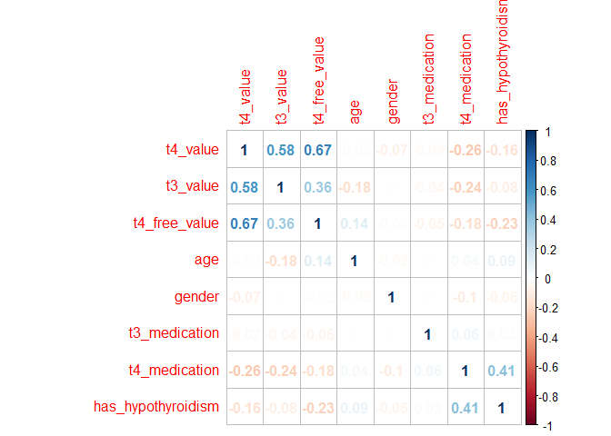

```r
corrplot((c),method = "number")
```

## Univariate distribution

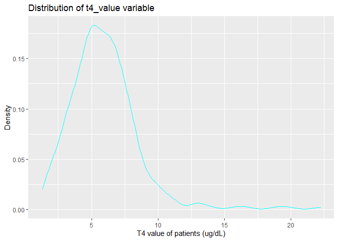

```r
g <- ggplot(final_df, aes(x = t4_value))
g + geom_density(color = "cyan") +
  ggtitle("Distribution of t4_value variable") +
  xlab("T4 value of patients (ug/dL)") + ylab("Density")
```

The distribution of T4 value of patients (ug/dL) present in this dataframe shows that most of the patients have values around the peak of 5ug/dL.

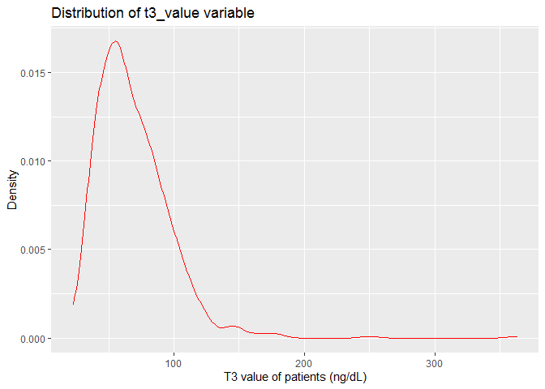

```r
g1 <- ggplot(final_df, aes(x = t3_value))
g1 + geom_density(color = "red") +
  ggtitle("Distribution of t3_value variable") +
  xlab("T3 value of patients (ng/dL)") + ylab("Density")
```

The distribution of T3 value of patients (ng/dL) present in this dataframe shows that most of the patients have values around the peak of 50ng/dL.

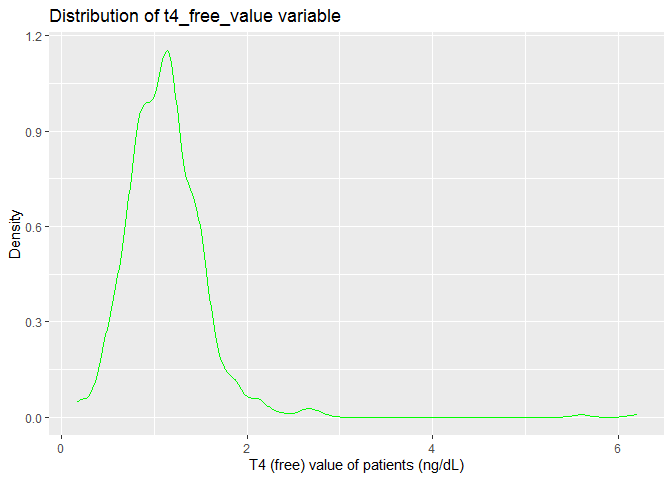

```r
g2 <- ggplot(final_df, aes(x = t4_free_value))
g2 + geom_density(color = "green") +
  ggtitle("Distribution of t4_free_value variable") +
  xlab("T4 (free) value of patients (ng/dL)") + ylab("Density")
```

The distribution of T4 (free) value of patients (ng/dL) present in this dataframe shows that most of the patients have values around the peak of 1.2ng/dL.

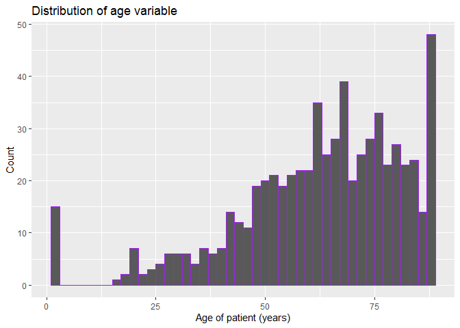

```r
g3 <- ggplot(final_df, aes(x = age))
g3 + geom_histogram(binwidth = 2, color = "purple") +
  ggtitle("Distribution of age variable") +
  xlab("Age of patient (years)") + ylab("Count")
```

The distribution of age of patients (years) present in this dataframe shows that more than half of the patients are older than 50years of age.

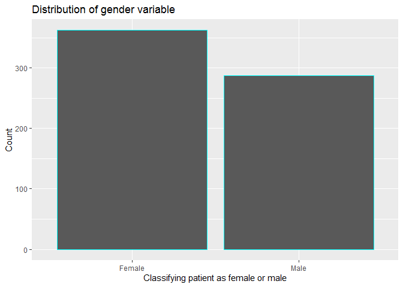

```r
g4 <- ggplot(final_df, aes(x = gender))
g4 + geom_bar(color = "cyan") +
  ggtitle("Distribution of gender variable") +
  xlab("Classifying patient as female or male") + ylab("Count")
```

The distribution of gender of patients present in this dataframe shows that there are more female patients than male patients.

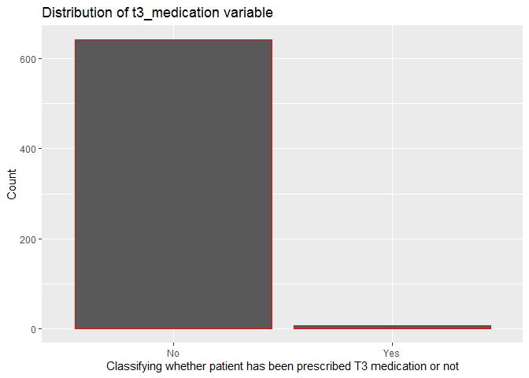

```r
g5 <- ggplot(final_df, aes(x = t3_medication))
g5 + geom_bar(color = "red") +
  ggtitle("Distribution of t3_medication variable") +
  xlab("Classifying whether patient has been prescribed T3 medication or not") + ylab("Count")
```

The distribution of whether patients present in this dataframe have been prescribed T3 medication or not shows that there are way more patients who have not been prescribed T3 medication than who have been prescribed T3 medication.

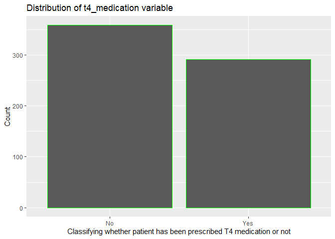

```r
g6 <- ggplot(final_df, aes(x = t4_medication))
g6 + geom_bar(color = "green") +
  ggtitle("Distribution of t4_medication variable") +
  xlab("Classifying whether patient has been prescribed T4 medication or not") + ylab("Count")
```

The distribution of whether patients present in this dataframe have been prescribed T4 medication or not shows that there are slightly more patients who have not been prescribed T4 medication than who have been prescribed T4 medication.

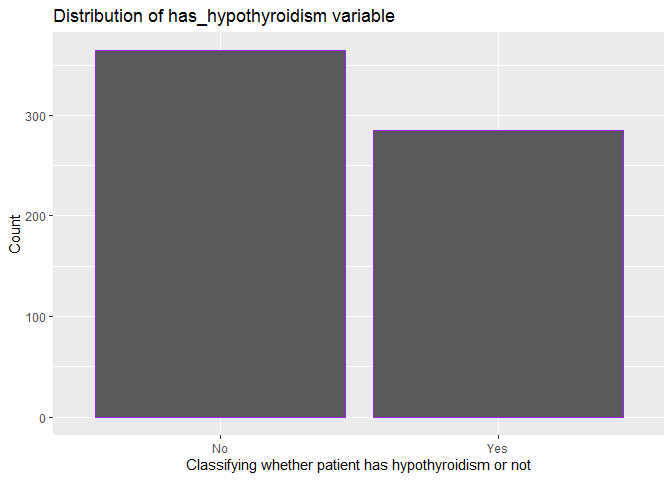

```r
g7 <- ggplot(final_df, aes(x = has_hypothyroidism))
g7 + geom_bar(color = "purple") +
  ggtitle("Distribution of has_hypothyroidism variable") +
  xlab("Classifying whether patient has hypothyroidism or not") + ylab("Count")
```

The distribution of whether patients present in this dataframe have hypothyroidism or not shows that there are slightly more patients who do not have hypothyroidism than who have hypothyroidism.